# PPP Loans Analysis

2022-07-08

## PPP Loans - Puprose and Impact

The Paycheck Protection Program (PPP) is a $953-billion business loan program established by the United States federal government, led by the Donald Trump administration in 2020 through the Coronavirus Aid, Relief, and Economic Security Act (CARES Act) to help certain businesses, self-employed workers, sole proprietors, certain non-profit organizations, and tribal businesses continue paying their workers.

According to a 2022 study, the PPP: cumulatively preserved between 2 and 3 million job-years of employment over 14 months at a cost of USD 169K to USD 258K per job-year retained. These numbers imply that only 23 to 34 percent of PPP dollars went directly to workers who would otherwise have lost jobs; the balance flowed to business owners and shareholders, including creditors and suppliers of PPP-receiving firms. Program incidence was ultimately highly regressive, with about three-quarters of PPP funds accruing to the top quintile of households. PPP’s breakneck scale-up, its high cost per job saved, and its regressive incidence have a common origin: PPP was essentially not specifically targeted because the United States lacked the administrative infrastructure to do otherwise. Harnessing modern administrative systems, other high-income countries were able to better target pandemic business aid to firms in financial distress. Building similar capacity in the U.S. would enable improved targeting when the next pandemic or other large-scale economic emergency inevitably arises.

Data source: https://data.sba.gov/dataset/ppp-foia File name: public_150k_plus_220703.csv

- **Research Questions**
1. How many, what amount and when were the PPP loans granted?
2. Did low income communities benefit from the loans?
3. Which banks led the processing of PPP loans?
4. Did the industries hardest hit by COVID-19 benefit from the loans?
5. Which industries and business types benefited from the PPP loans?
6. Are there differences in the average loan amounts granted across business types and industries?
7. Are there any outliers or evidence of Fraud in the data?
8. Did certain states benefit more than the others?

### The code below runs after data pre-processing

Loading key libraries used for the analysis and setting up a global table format (via a function):

```r
library(dplyr)
```

```r
library(ggplot2)
library(lubridate)
library(tidyverse)
library(formattable)
library(gt)
library(scales)
library(knitr)

gt_theme_538 <- function(data,...) {
  data %>%
    opt_all_caps()  %>%
    opt_table_font(
      font = list(
        google_font("Chivo"),
        default_fonts()
      )
    ) %>%
    tab_style(
      style = cell_borders(
        sides = "bottom", color = "transparent", weight = px(2)
      ),
      locations = cells_body(
        columns = TRUE,
        # This is a relatively sneaky way of changing the bottom border
        # Regardless of data size
        rows = nrow(data$`_data`)
      )
    )  %>%
    tab_options(
      column_labels.background.color = "white",
      table.border.top.width = px(3),
      table.border.top.color = "transparent",
      table.border.bottom.color = "transparent",
      table.border.bottom.width = px(3),
      column_labels.border.top.width = px(3),
      column_labels.border.top.color = "transparent",
      column_labels.border.bottom.width = px(3),
      column_labels.border.bottom.color = "black",
      data_row.padding = px(3),
      source_notes.font.size = 12,
      table.font.size = 16,
      heading.align = "left",
      ...
    )
}
```

Load Clean Data and Starting Analysis 1. Calculate the total loans in the dataset, the key loan metrics used are: total loan count, total jobs saved (or reported by the borrower), total current loan amt (this aggregated all draws made by the borrower), avearge current loan amount, median current loan amount and standard deviation of current loan amount.

```r
setwd("~/Desktop/NYCDSA/R/R_Data_Analysis")
ppp_loans <- readr::read_csv("export_data_ppp_loans.csv")
bal_sum = ppp_loans%>%
  summarise(total_loan_cnt = n(),
            total_jobs = sum(JobsReported),
            total_curr_amt = sum(CurrentApprovalAmount),
            avg_curr_amt = mean(CurrentApprovalAmount),
            med_curr_amt = median(CurrentApprovalAmount),
            sd_curr_amt = sd(CurrentApprovalAmount)
            )%>%
  arrange(desc(total_curr_amt))

gt(data=bal_sum)%>%
  gt_theme_538() %>%
   tab_header(title = "Total PPP Loans Granted (2020-2021)")%>%
   fmt_currency(
     columns = c(total_curr_amt, avg_curr_amt, med_curr_amt,sd_curr_amt),
     currency = "USD",
     decimals = 0,
     suffixing = TRUE
   ) %>% cols_label(
     total_loan_cnt = md("**Total Loan Count**"),
     total_jobs = md("**Total Jobs Saved**"),
     total_curr_amt = md("**Total Loan Amt**"),
     avg_curr_amt = md("**Average Loan Amt**"),
     med_curr_amt = md("**Median Loan Amt**"),
     sd_curr_amt = md("**Std. Dev of Loan Amt**")) %>%
  opt_align_table_header("left")
```

Total PPP Loans Granted (2020-2021)

| **Total Loan Count** | **Total Jobs Saved** | **Total Loan Amt** | **Average Loan Amt** | **Median Loan Amt** | **Std. Dev of Loan Amt** |
| --- | --- | --- | --- | --- | --- |
| 968532 | 50253958 | $514B | $531K | $295K | $738K |

2. Loan metrics split by Industry Type (as defined by 2 digit NACIS codes).

```r
bal_sum1 = ppp_loans%>%
  group_by(Industry)%>%
  summarise(total_loan_cnt = n(),
            total_jobs = sum(JobsReported),
            total_curr_amt = sum(CurrentApprovalAmount),
            avg_curr_amt = mean(CurrentApprovalAmount),
            med_curr_amt = median(CurrentApprovalAmount),
            sd_curr_amt = sd(CurrentApprovalAmount)
            )%>%
  arrange(desc(total_curr_amt))


gt(data=bal_sum1)%>%
  gt_theme_538() %>%
   tab_header(title = "PPP Loans by Industry")%>%
   fmt_currency(
     columns = c(total_curr_amt, avg_curr_amt, med_curr_amt,sd_curr_amt),
     currency = "USD",
     decimals = 0,
     suffixing = TRUE
   ) %>% cols_label(
     total_loan_cnt = md("**Total Loan Count**"),
     total_jobs = md("**Total Jobs Saved**"),
     total_curr_amt = md("**Total Loan Amt**"),
     avg_curr_amt = md("**Average Loan Amt**"),
     med_curr_amt = md("**Median Loan Amt**"),
     sd_curr_amt = md("**Std. Dev of Loan Amt**")) %>%
  opt_align_table_header("left")
```

PPP Loans by Industry

| Industry | **Total Loan Count** | **Total Jobs Saved** | **Total Loan Amt** | **Average Loan Amt** | **Median Loan Amt** | **Std. Dev of Loan Amt** |
| --- | --- | --- | --- | --- | --- | --- |
| Construction | 128579 | 5206424 | $70B | $548K | $312K | $734K |
| Health Care and Social Assistance | 117537 | 7308418 | $64B | $544K | $280K | $807K |
| Manufacturing | 101062 | 5406338 | $63B | $624K | $350K | $832K |
| Professional, Scientific, and Technical Services | 116021 | 4301455 | $62B | $536K | $299K | $747K |
| Accommodation and Food Services | 124756 | 7789589 | $55B | $442K | $262K | $643K |
| Retail Trade | 63496 | 3412280 | $33B | $522K | $307K | $619K |
| Wholesale Trade | 50408 | 2319807 | $28B | $556K | $313K | $723K |
| Admin Support and Waste Mgt Services | 44657 | 2911317 | $25B | $565K | $300K | $845K |
| Other Services (except Public Administration) | 57882 | 2811190 | $25B | $428K | $257K | $574K |
| Transportation and Warehousing | 32072 | 1634645 | $17B | $530K | $299K | $734K |
| Educational Services | 20026 | 1433025 | $13B | $643K | $348K | $808K |
| Real Estate Rental and Leasing | 23526 | 1062830 | $12B | $515K | $292K | $676K |
| Information | 16368 | 717744 | $10B | $595K | $320K | $865K |
| Arts, Entertainment, and Recreation | 16919 | 1176088 | $8B | $484K | $282K | $619K |
| Finance and Insurance | 15268 | 585554 | $8B | $516K | $278K | $765K |
| Agriculture, Forestry, Fishing and Hunting | 13373 | 778345 | $6B | $450K | $267K | $552K |
| Mining | 8411 | 362461 | $6B | $682K | $360K | $1M |
| Unknown | 10720 | 637599 | $4B | $349K | $229K | $452K |
| Public Administration | 2966 | 154045 | $2B | $562K | $293K | $792K |
| Management of Companies and Enterprises | 2168 | 146463 | $2B | $723K | $352K | $1M |
| Utilities | 2317 | 98341 | $1B | $638K | $353K | $868K |

```r
bal_sum1 = ppp_loans%>%
  group_by(BusinessType)%>%
  summarise(total_loan_cnt = n(),
            total_jobs = sum(JobsReported),
            total_curr_amt = sum(CurrentApprovalAmount),
            avg_curr_amt = mean(CurrentApprovalAmount),
            med_curr_amt = median(CurrentApprovalAmount),
            sd_curr_amt = sd(CurrentApprovalAmount)
            )%>%
  arrange(desc(total_curr_amt))


gt(data=bal_sum1)%>%
  gt_theme_538() %>%
   tab_header(title = "PPP Loans by Business Type")%>%
   fmt_currency(
     columns = c(total_curr_amt, avg_curr_amt, med_curr_amt,sd_curr_amt),
     currency = "USD",
     decimals = 0,
     suffixing = TRUE
   ) %>% cols_label(
     total_loan_cnt = md("**Total Loan Count**"),
     total_jobs = md("**Total Jobs Saved**"),
     total_curr_amt = md("**Total Loan Amt**"),
     avg_curr_amt = md("**Average Loan Amt**"),
     med_curr_amt = md("**Median Loan Amt**"),
     sd_curr_amt = md("**Std. Dev of Loan Amt**")) %>%
  opt_align_table_header("left")
```

PPP Loans by Business Type

| BusinessType | **Total Loan Count** | **Total Jobs Saved** | **Total Loan Amt** | **Average Loan Amt** | **Median Loan Amt** | **Std. Dev of Loan Amt** |
| --- | --- | --- | --- | --- | --- | --- |
| Corporation | 417853 | 20243756 | $216B | $518K | $294K | $708K |
| Limited Liability Company(LLC) | 261295 | 13570127 | $130B | $498K | $283K | $693K |
| Subchapter S Corporation | 175408 | 8971612 | $96B | $547K | $302K | $753K |
| Non-Profit Organization | 55699 | 4419740 | $39B | $699K | $360K | $906K |
| Partnership | 18141 | 931213 | $10B | $559K | $310K | $801K |
| Limited Liability Partnership | 12722 | 622714 | $7B | $537K | $304K | $748K |
| Sole Proprietorship | 12319 | 525091 | $5B | $410K | $234K | $618K |
| Professional Association | 6384 | 335402 | $3B | $512K | $277K | $747K |
| 501(c)3 – Non Profit | 1771 | 242735 | $3B | $1M | $500K | $2M |
| Cooperative | 2436 | 130141 | $2B | $649K | $346K | $838K |
| Employee Stock Ownership Plan(ESOP) | 638 | 65241 | $920M | $1M | $858K | $2M |
| Unknown | 722 | 47823 | $538M | $745K | $425K | $1M |
| Non-Profit Childcare Center | 900 | 57199 | $428M | $476K | $281K | $561K |
| 501(c)6 – Non Profit Membership | 764 | 23900 | $377M | $494K | $289K | $603K |
| Trust | 403 | 24997 | $296M | $735K | $388K | $1M |
| Self-Employed Individuals | 495 | 15691 | $175M | $354K | $234K | $361K |
| Joint Venture | 129 | 7875 | $78M | $604K | $300K | $959K |
| Housing Co-op | 152 | 3622 | $54M | $357K | $234K | $325K |
| Tribal Concerns | 64 | 6737 | $53M | $826K | $472K | $856K |
| Independent Contractors | 113 | 3816 | $43M | $382K | $266K | $296K |
| Single Member LLC | 77 | 2651 | $27M | $345K | $207K | $359K |
| Tenant in Common | 30 | 1156 | $10M | $334K | $244K | $258K |
| 501(c) – Non Profit except 3,4,6, | 10 | 478 | $4M | $374K | $261K | $325K |
| Rollover as Business Start-Ups (ROB | 3 | 96 | $1M | $335K | $415K | $142K |
| 501(c)19 – Non Profit Veterans | 2 | 92 | $481K | $241K | $241K | $66K |
| Qualified Joint-Venture (spouses) | 2 | 53 | $430K | $215K | $215K | $52K |

4. Loan metrics split by Business Age.

```r
bal_sum2 = ppp_loans%>%
  group_by(BusinessAgeDescription)%>%
  summarise(total_loan_cnt = n(),
            total_jobs = sum(JobsReported),
            total_curr_amt = sum(CurrentApprovalAmount),
            avg_curr_amt = mean(CurrentApprovalAmount),
            med_curr_amt = median(CurrentApprovalAmount),
            sd_curr_amt = sd(CurrentApprovalAmount)
            )%>%
  arrange(desc(total_curr_amt))


gt(data=bal_sum2)%>%
  gt_theme_538() %>%
   tab_header(title = "PPP Loans by Business Age")%>%
   fmt_currency(
     columns = c(total_curr_amt, avg_curr_amt, med_curr_amt,sd_curr_amt),
     currency = "USD",
     decimals = 0,
     suffixing = TRUE
   ) %>% cols_label(
     total_loan_cnt = md("**Total Loan Count**"),
     total_jobs = md("**Total Jobs Saved**"),
     total_curr_amt = md("**Total Loan Amt**"),
     avg_curr_amt = md("**Average Loan Amt**"),
     med_curr_amt = md("**Median Loan Amt**"),
     sd_curr_amt = md("**Std. Dev of Loan Amt**")) %>%
  opt_align_table_header("left")
```

PPP Loans by Business Age

| BusinessAgeDescription | **Total Loan Count** | **Total Jobs Saved** | **Total Loan Amt** | **Average Loan Amt** | **Median Loan Amt** | **Std. Dev of Loan Amt** |
| --- | --- | --- | --- | --- | --- | --- |
| Existing or more than 2 years old | 861917 | 44563835 | $455B | $528K | $296K | $727K |
| Unanswered | 51052 | 2884921 | $31B | $605K | $303K | $909K |
| New Business or 2 years or less | 54851 | 2762613 | $27B | $497K | $273K | $722K |
| Change of Ownership | 422 | 25165 | $292M | $692K | $311K | $1M |
| Startup, Loan Funds will Open Business | 290 | 17424 | $181M | $623K | $276K | $924K |

5. Loan metrics split by Rural and Urban communities.

```r
bal_sum3 = ppp_loans%>%
  group_by(RuralUrbanIndicator)%>%
  summarise(total_loan_cnt = n(),
            total_curr_amt = sum(CurrentApprovalAmount),
            med_curr_amt = median(CurrentApprovalAmount)
            )%>%
  arrange(desc(total_curr_amt))


gt(data=bal_sum3)%>%
  gt_theme_538() %>%
   tab_header(title = "PPP Loans by Rural Urban Communities")%>%
   fmt_currency(
     columns = c(total_curr_amt, med_curr_amt),
     currency = "USD",
     decimals = 0,
     suffixing = TRUE
   ) %>% cols_label(
     RuralUrbanIndicator = md("**Urban/Rural**"),
     total_loan_cnt = md("**Total Loan Count**"),
     total_curr_amt = md("**Total Loan Amt**"),
     med_curr_amt = md("**Median Loan Amt**"))%>%
  opt_align_table_header("left")
```

PPP Loans by Rural Urban Communities

| **Urban/Rural** | **Total Loan Count** | **Total Loan Amt** | **Median Loan Amt** |
| --- | --- | --- | --- |
| U | 823900 | $443B | $298K |
| R | 144632 | $71B | $281K |

6. Loan metrics split by Low to Moderate income communities.

```r
bal_sum3 = ppp_loans%>%
  group_by(LMIIndicator)%>%
  summarise(total_loan_cnt = n(),
            total_curr_amt = sum(CurrentApprovalAmount),
            med_curr_amt = median(CurrentApprovalAmount)
            )%>%
  arrange(desc(total_curr_amt))


gt(data=bal_sum3)%>%
  gt_theme_538() %>%
   tab_header(title = "PPP Loans by Low to Moderate Income Communities")%>%
   fmt_currency(
     columns = c(total_curr_amt, med_curr_amt),
     currency = "USD",
     decimals = 0,
     suffixing = TRUE
   ) %>% cols_label(
     LMIIndicator = md("**Low/Moderate Income**"),
     total_loan_cnt = md("**Total Loan Count**"),
     total_curr_amt = md("**Total Loan Amt**"),
     med_curr_amt = md("**Median Loan Amt**"))%>%
  opt_align_table_header("left")
```

PPP Loans by Low to Moderate Income Communities

| **Low/Moderate Income** | **Total Loan Count** | **Total Loan Amt** | **Median Loan Amt** |
| --- | --- | --- | --- |
| N | 713918 | $377B | $293K |
| Y | 254614 | $137B | $300K |

7. Example of detecting outliers, where some data is missing and loan amounts exceed 3 times the median loan amount.

```r
ppp_loans%>%
  filter(BusinessAgeDescription == "Unanswered" &
           BusinessType == "Unknown" &
           CurrentApprovalAmount > 3*median(CurrentApprovalAmount, na.rm = TRUE)) %>%
  select(BorrowerName, JobsReported, OriginatingLender, CurrentApprovalAmount, Industry, State)%>%
   gt() %>%
  gt_theme_538() %>%
  tab_header(title = md("**Outliers and Possible Fraud**"))
```

**Outliers and Possible Fraud**

| BorrowerName | JobsReported | OriginatingLender | CurrentApprovalAmount | Industry | State |
| --- | --- | --- | --- | --- | --- |
| S.S. HERT TRUCKING, INC. | 78 | The Huntington National Bank | 1139877 | Transportation and Warehousing | California |
| MSSL WIRING SYSTEM INC. | 384 | The Huntington National Bank | 4269545 | Unknown | Ohio |
| THE ROBBINS COMPANY | 107 | KeyBank National Association | 3395572 | Manufacturing | Ohio |
| REGINA HEALTH CENTER | 190 | KeyBank National Association | 1303369 | Health Care and Social Assistance | Ohio |

8. Another example of detecting outliers, where loan amounts exceed 2M and loan to job ratio is high.

```r
ppp_loans%>%
  filter(CurrentApprovalAmount>2000000)%>%
  select(BorrowerName, JobsReported, CurrentApprovalAmount, Industry, State)%>%
  mutate(loan_job_ratio = CurrentApprovalAmount/JobsReported)%>%
  top_n(10)%>%
   gt() %>%
  gt_theme_538() %>%
  tab_header(title = md("**Outliers**"))
```

**Outliers**

| BorrowerName | JobsReported | CurrentApprovalAmount | Industry | State | loan_job_ratio |
| --- | --- | --- | --- | --- | --- |
| NAZARETH HOME, INC. | 1 | 3013797 | Health Care and Social Assistance | Kentucky | 3013797 |
| JENA BAND OF CHOCTAW INDIANS | 1 | 2460000 | Arts, Entertainment, and Recreation | Louisiana | 2460000 |
| TREGO/DUGAN AVIATION, INC | 1 | 4247700 | Transportation and Warehousing | Nebraska | 4247700 |
| MOLDCABLE INC | 1 | 3726400 | Information | New Jersey | 3726400 |
| SH GROUP, INC. | 2 | 9480024 | Professional, Scientific, and Technical Services | New York | 4740012 |
| PREMIER CARE STAFFING | 1 | 6512998 | Admin Support and Waste Mgt Services | New York | 6512998 |
| MILLER TRUCK LINES LLC | 1 | 3408380 | Transportation and Warehousing | Oklahoma | 3408380 |
| PENNROSE MANAGEMENT COMPANY | 1 | 5131282 | Real Estate Rental and Leasing | Pennsylvania | 5131282 |
| B. J. BALDWIN ELECTRIC, INC | 1 | 4711700 | Construction | Pennsylvania | 4711700 |
| EN SU CASA PRIMARY HOME CARE SERVICE, INC. | 1 | 2620000 | Health Care and Social Assistance | Texas | 2620000 |

```r
ppp_loans%>%
  filter(CurrentApprovalAmount<max(CurrentApprovalAmount))%>%
  filter(JobsReported > 10 & JobsReported < 50)%>%
  filter(BusinessAgeDescription == "New Business or 2 years or less")%>%
  select(BorrowerName, BorrowerState,
         Industry, CurrentApprovalAmount, JobsReported)%>%
  mutate(LTJ_ratio = CurrentApprovalAmount/JobsReported )%>%
  arrange(desc(LTJ_ratio))%>%
  top_n(10)%>%
  gt() %>%
  gt_theme_538() %>%
  tab_header(title = md("**Fraud or Outliers**"))
```

**Fraud or Outliers**

| BorrowerName | BorrowerState | Industry | CurrentApprovalAmount | JobsReported | LTJ_ratio |
| --- | --- | --- | --- | --- | --- |
| AZHAR SARWAR RANA, LLC | NJ | Finance and Insurance | 5677473 | 11 | 516133.9 |
| ROAD DOCTOR CALIFORNIA LLC | CA | Unknown | 7250000 | 20 | 362500.0 |
| RUD MANAGEMENT, LLC | IL | Admin Support and Waste Mgt Services | 8519471 | 27 | 315536.0 |
| QUICKSERVE ENTERPRISES INC | CA | Accommodation and Food Services | 6212690 | 22 | 282395.0 |
| PROMASTER MOVERS, INC. | FL | Transportation and Warehousing | 3179342 | 13 | 244564.8 |
| LITTLE SPROUTS, LLC | MA | Health Care and Social Assistance | 4740032 | 20 | 237001.6 |
| PROJECT DESIGN LLC | IN | Construction | 3903857 | 18 | 216880.9 |
| PF MICHIGAN GROUP, LLC | MI | Arts, Entertainment, and Recreation | 4170862 | 20 | 208543.1 |
| YELLOWHAMMER SALON GROUP LLC | AL | Other Services (except Public Administration) | 2620200 | 14 | 187157.1 |
| WAVE COMPUTING, INC. | CA | Manufacturing | 4609422 | 29 | 158945.6 |

9. Boxplot by industry, the scale used here is log10 for better visualization.

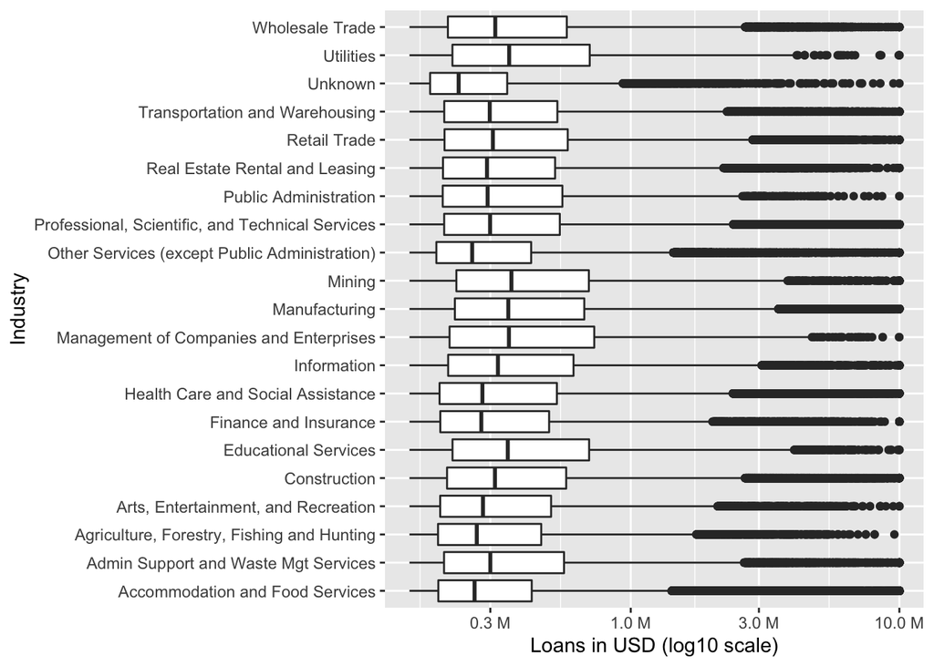

```r
# boxplots by Industry type
p <- ggplot(ppp_loans, aes(x=Industry, y=CurrentApprovalAmount)) +
  geom_boxplot() +
  scale_y_continuous(trans = "log10", name="Loans in USD (log10 scale)", labels = label_number(suffix = " M", scale = 1e-6)) +
  coord_flip()
p
```

10. Histogram to evaluate loan amount distribution.

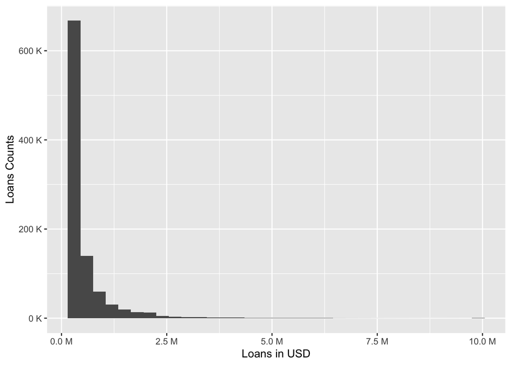

```r
ggplot(ppp_loans, aes(x=CurrentApprovalAmount)) +
  geom_histogram(binwidth = 300000) +
  scale_x_continuous(name="Loans in USD", labels = label_number(suffix = " M", scale = 1e-6)) +
    scale_y_continuous(name="Loans Counts", labels = label_number(suffix = " K", scale = 1e-3))
```

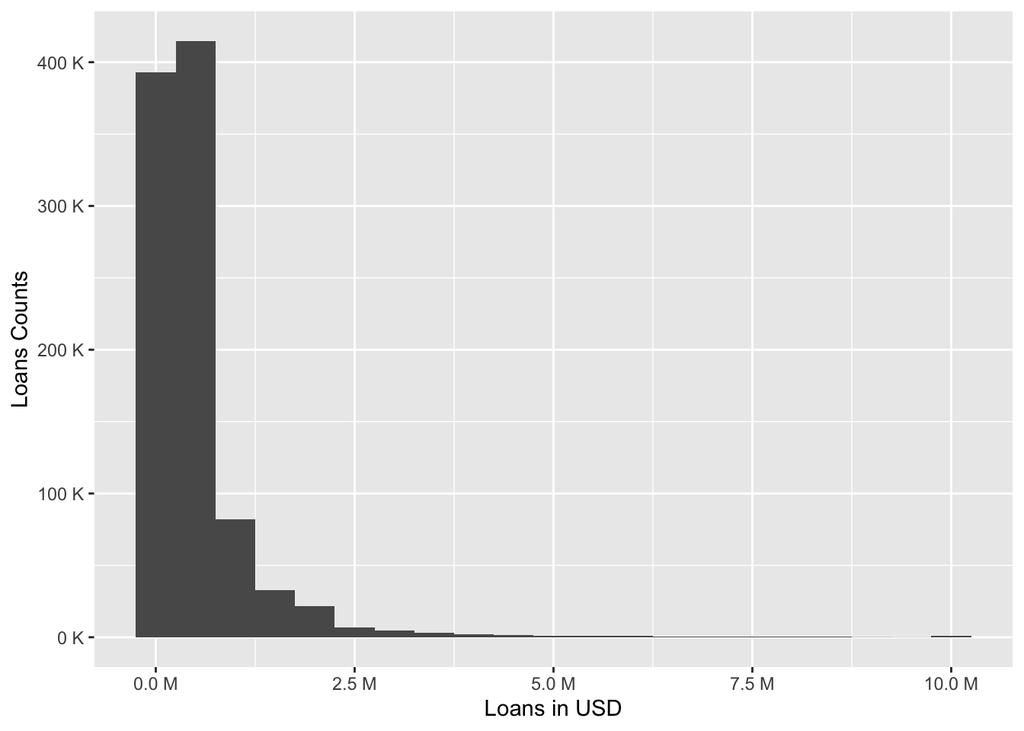

```r
ggplot(ppp_loans, aes(x=CurrentApprovalAmount)) +
  geom_histogram(binwidth = 500000) +
  scale_x_continuous(name="Loans in USD", labels = label_number(suffix = " M", scale = 1e-6)) +
    scale_y_continuous(name="Loans Counts", labels = label_number(suffix = " K", scale = 1e-3))
```

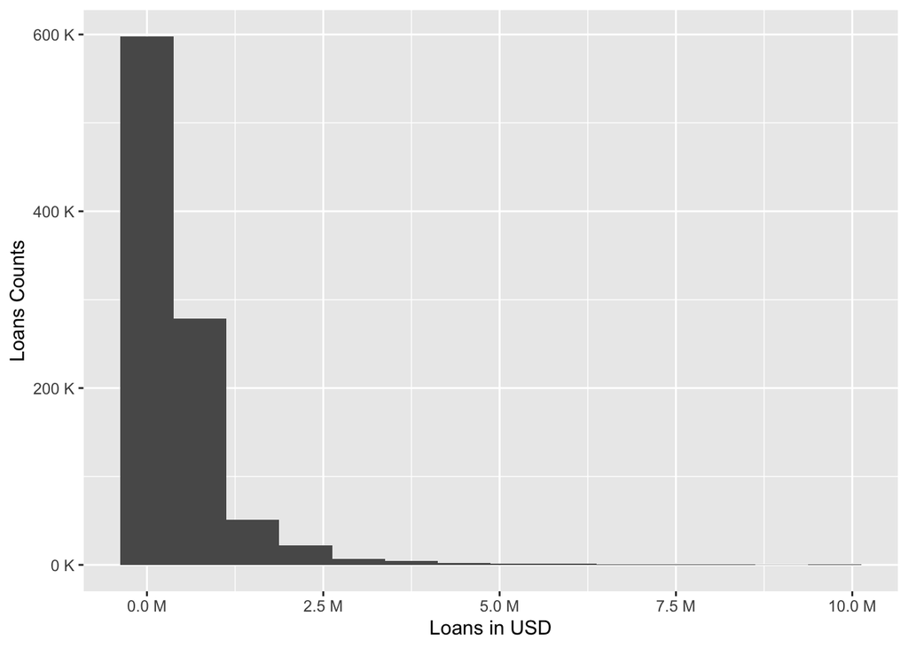

```r
ggplot(ppp_loans, aes(x=CurrentApprovalAmount)) +
  geom_histogram(binwidth = 750000) +
  scale_x_continuous(name="Loans in USD", labels = label_number(suffix = " M", scale = 1e-6)) +
    scale_y_continuous(name="Loans Counts", labels = label_number(suffix = " K", scale = 1e-3))
```

11. Boxplot by business type, the scale used here is log10 for better visualization.

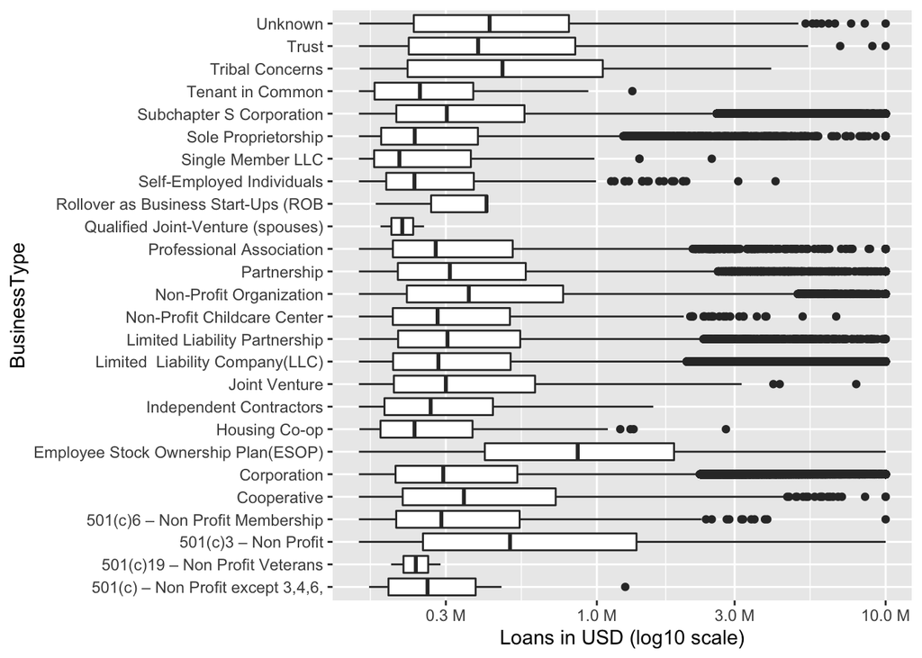

```r
# boxplots by business type
p <- ggplot(ppp_loans, aes(x=BusinessType, y=CurrentApprovalAmount)) +
  geom_boxplot() +
  scale_y_continuous(trans='log10', name="Loans in USD (log10 scale)", labels = label_number(suffix = " M", scale = 1e-6)) +
  coord_flip()
p
```

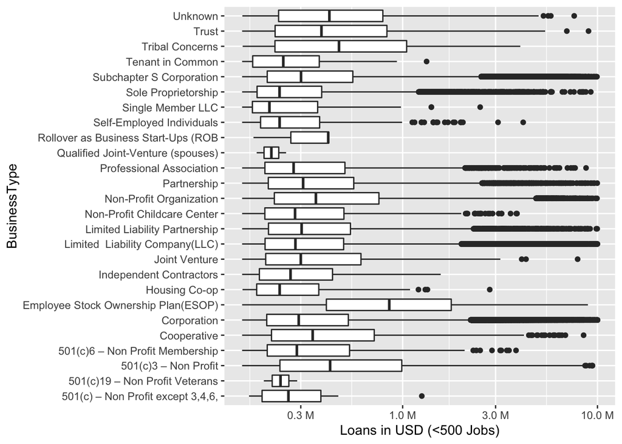

```r
# boxplots by business type
sub_ppp = ppp_loans%>%
  filter(JobsReported <500)%>%
  filter(CurrentApprovalAmount<max(CurrentApprovalAmount))

p <- ggplot(sub_ppp, aes(x=BusinessType, y=CurrentApprovalAmount)) +
  geom_boxplot() +
  scale_y_continuous(trans='log10', name="Loans in USD (<500 Jobs)", labels = label_number(suffix = " M", scale = 1e-6)) +
  coord_flip()
p
```

12. Loan trend over time, using month and year time series.

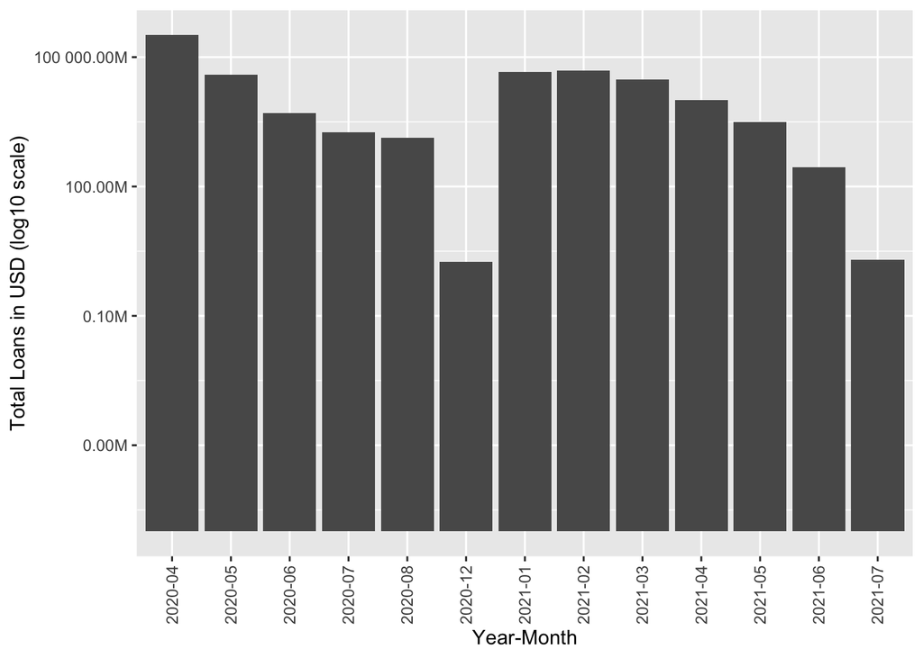

```r
q <- ppp_loans%>%
  group_by(Month_Yr)%>%
  summarise(Total_Loans = sum(CurrentApprovalAmount))%>%
  ggplot() + geom_col(aes(x=Month_Yr, y=Total_Loans)) +
  scale_y_continuous(trans='log10',
                     labels = label_number(suffix = "M", scale = 1e-6)
  ) +
  labs(x = "Year-Month", y="Total Loans in USD (log10 scale)")

q + theme(axis.text.x = element_text(angle = 90, vjust = 0.5, hjust=1))
```

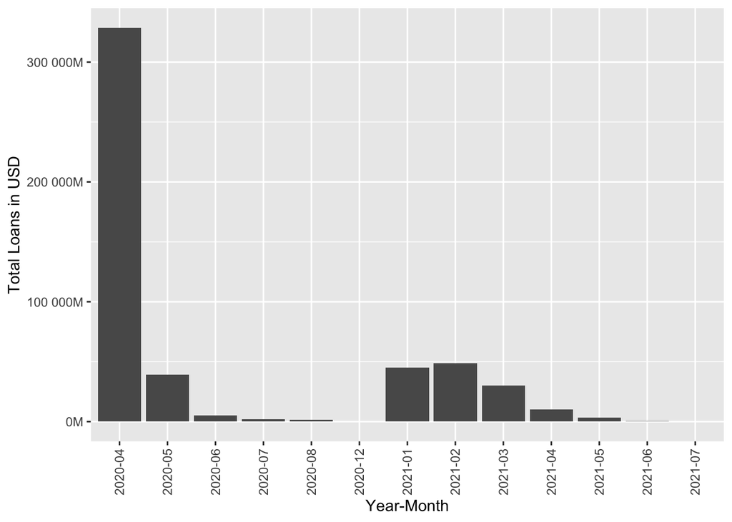

```r
q <- ppp_loans%>%
  group_by(Month_Yr)%>%
  summarise(Total_Loans = sum(CurrentApprovalAmount))%>%
  ggplot() + geom_col(aes(x=Month_Yr, y=Total_Loans)) +
  scale_y_continuous(
                     labels = label_number(suffix = "M", scale = 1e-6)
  ) +
  labs(x = "Year-Month", y="Total Loans in USD")

q + theme(axis.text.x = element_text(angle = 90, vjust = 0.5, hjust=1))
```

13. Loan trend over time, using month and year time series, split by Rural and Urban Indicator.

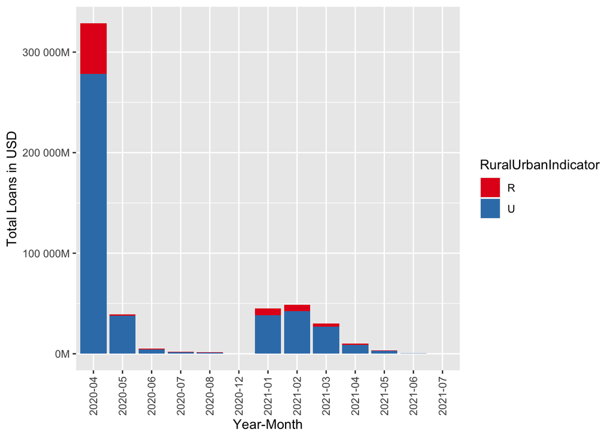

```r
q <- ppp_loans%>%
  group_by(Month_Yr, RuralUrbanIndicator)%>%
  summarise(Total_Loans = sum(CurrentApprovalAmount))%>%
  ggplot() + geom_col(aes(x=Month_Yr, y=Total_Loans, fill = RuralUrbanIndicator)) +
  scale_fill_brewer(palette="Set1") +
  scale_y_continuous(
                     labels = label_number(suffix = "M", scale = 1e-6)
  ) +
  labs(x = "Year-Month", y="Total Loans in USD")
q + theme(axis.text.x = element_text(angle = 90, vjust = 0.5, hjust=1))
```

14. Loan trend over time, using month and year time series, split by Low to Moderate Income Indicator.

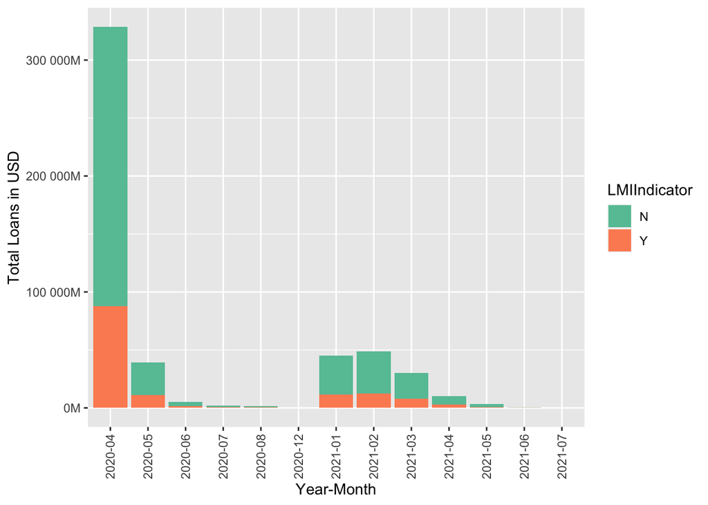

```r
q <- ppp_loans%>%
  group_by(Month_Yr, LMIIndicator)%>%
  summarise(Total_Loans = sum(CurrentApprovalAmount))%>%
  ggplot() + geom_col(aes(x=Month_Yr, y=Total_Loans, fill = LMIIndicator)) +
  scale_fill_brewer(palette="Set2") +
  scale_y_continuous(
                     labels = label_number(suffix = "M", scale = 1e-6)
  ) +
  labs(x = "Year-Month", y="Total Loans in USD")
q + theme(axis.text.x = element_text(angle = 90, vjust = 0.5, hjust=1))
```

15. Top 10 banks that benefited from distributing the loans.

```r
bank_bal <- ppp_loans%>%
  group_by(OriginatingLender)%>%
  summarise(Total_Loans = sum(CurrentApprovalAmount))%>%
  arrange(desc(Total_Loans)) %>%
  top_n(10)
```

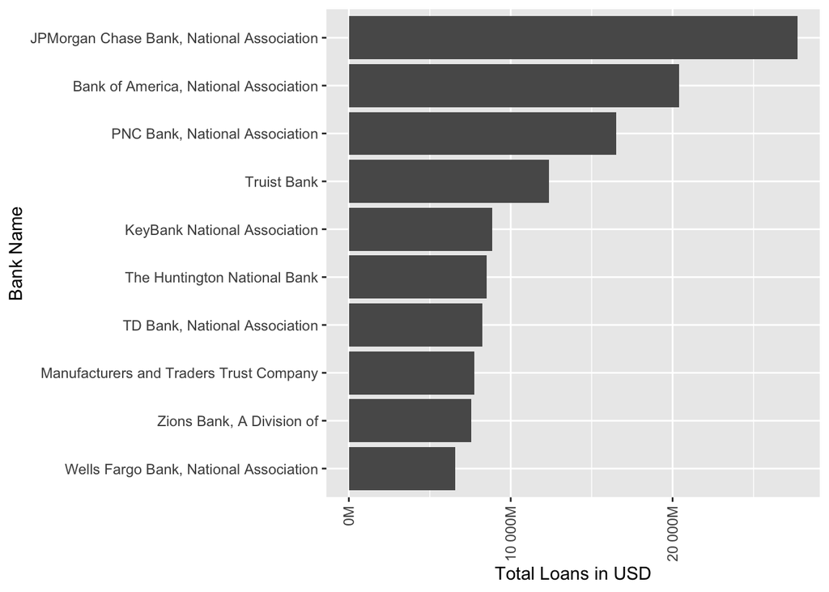

```r
q <- bank_bal%>%
  ggplot() +
  geom_col(aes(x=reorder(OriginatingLender, Total_Loans), y=Total_Loans)) +
  scale_y_continuous(
                     labels = label_number(suffix = "M", scale = 1e-6)
  ) +
  labs(x = "Bank Name", y="Total Loans in USD")

q + theme(axis.text.x = element_text(angle = 90, vjust = 0.5, hjust=1))  + coord_flip()
```

### Including USA Map

16. This analysis shows loan grants by state:
- The data processing here gets the state longitude and latitude, then plots the data on map in two ways:
  1. Loans by State
  2. Loans per Capita (Current Loan Amt/State Population)

```r
states <- map_data("state")

st_loans = ppp_loans%>%
  select(BorrowerState, State, Population,
         politics, Small_Business_Cnt,
         Employment_Estimate_2017,
         Annual_payroll_in_thousand,
         CurrentApprovalAmount)%>%
  mutate(region = tolower(State))%>%
  group_by(BorrowerState, State, region)%>%
  summarise(total_loan_amt = sum(CurrentApprovalAmount),
            st_pop = max(Population),
            sb_cnt = max(Small_Business_Cnt))%>%
  mutate(loan_pc = total_loan_amt/st_pop,
         loan_psb = total_loan_amt/sb_cnt)
tfmerged <- merge(states, st_loans, sort = FALSE, by = "region")
tfmerged <- tfmerged[order(tfmerged$order), ]
```

```r
gg <- ggplot()
gg <- gg + geom_map(data=tfmerged, map=states,
                    aes(x=long, y=lat, map_id=region),
                    fill="#ffffff", color="#ffffff", size=0.15)
gg <- gg + geom_map(data=tfmerged, map=states,
                    aes(fill=total_loan_amt, map_id=region),
                    color="#ffffff", size=0.15)

gg <- gg + scale_fill_continuous(low='thistle2', high='darkred',
                                 guide='colorbar',
                                 labels = label_number(suffix = " M", scale = 1e-6))
gg <- gg + labs(x=NULL, y=NULL)
gg <- gg + coord_map("albers", lat0 = 39, lat1 = 45)
gg <- gg + theme(panel.border = element_blank())
gg <- gg + theme(panel.background = element_blank())
gg <- gg + theme(axis.ticks = element_blank())
gg <- gg + theme(axis.text = element_blank())
gg <- gg + labs(fill="Loan Amount")
```

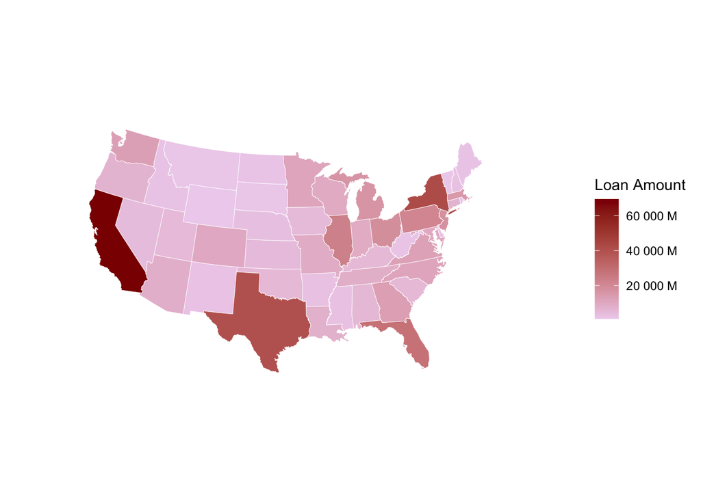

```r
gg
```

```r
pp <- ggplot()
pp <- pp + geom_map(data=tfmerged, map=states,
                    aes(x=long, y=lat, map_id=region),
                    fill="#ffffff", color="#ffffff", size=0.15)
pp <- pp + geom_map(data=tfmerged, map=states,
                    aes(fill=loan_pc, map_id=region),
                    color="#ffffff", size=0.15)

pp <- pp + scale_fill_continuous(low='thistle2', high='darkred',
                                 guide='colorbar',
                                 labels = label_number(suffix = " K", scale = 1e-3))
pp <- pp + labs(x=NULL, y=NULL)
pp <- pp + coord_map("albers", lat0 = 39, lat1 = 45)
pp <- pp + theme(panel.border = element_blank())
pp <- pp + theme(panel.background = element_blank())
pp <- pp + theme(axis.ticks = element_blank())
pp <- pp + theme(axis.text = element_blank())
pp <- pp + labs(fill="Loan Amount per Capita")
```

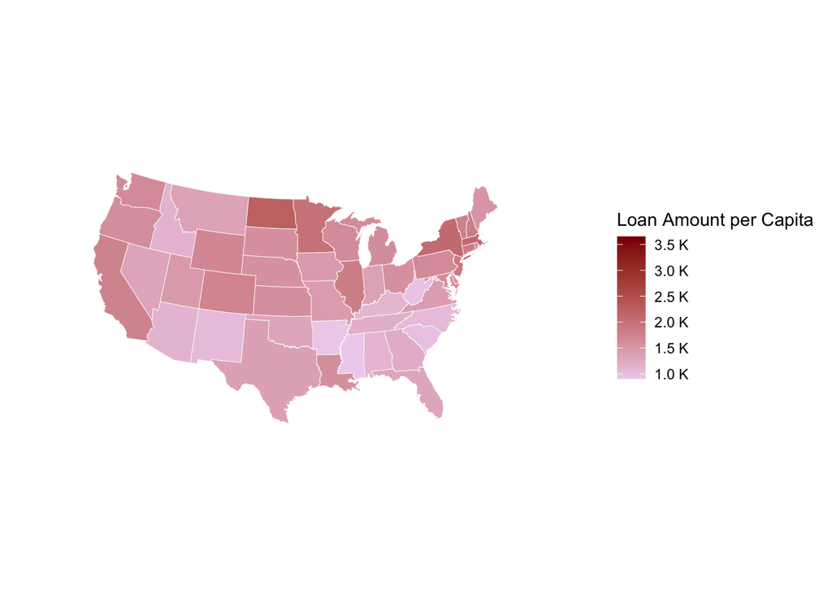

```r
pp
```

End of Analysis